# projekt

## Budowa macierzy korelacji

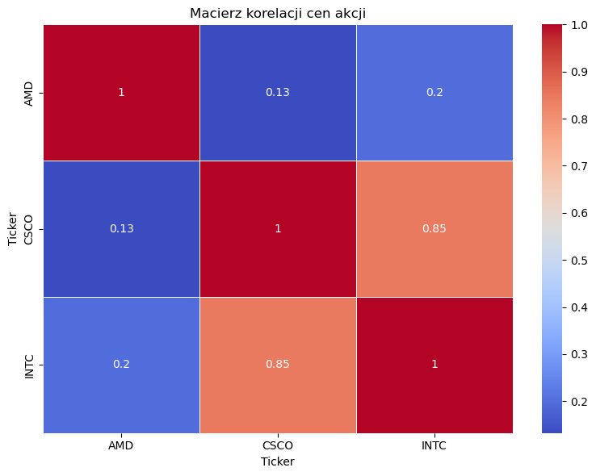

```python
macierz_korelacji = ceny.corr()

plt.figure(figsize=(8, 6))
sns.heatmap(macierz_korelacji, annot=True, cmap='coolwarm', linewidths=.5)
plt.title('Macierz korelacji cen akcji')
plt.tight_layout()
plt.show()
```

Otrzymana macierz korelacji pokazuje współczynniki korelacji między trzema tickerami: AMD, CSCO, i INTC. Korelacja mierzy siłę i kierunek związku liniowego między dwiema zmiennymi. Wartości korelacji mieszczą się w zakresie od -1 do 1.

##### Interpretacja macierzy korelacji:

- AMD i CSCO: Wartość korelacji wynosi 0.13 - to wskazuje na bardzo słabą dodatnią korelację między cenami AMD i CSCO. Oznacza to, że zmiany cen AMD mają bardzo mały wpływ na zmiany cen CSCO i vice versa.
- AMD i INTC: Wartość korelacji wynosi 0.2 - to również wskazuje na słabą dodatnią korelację między cenami AMD i INTC. Oznacza to, że zmiany cen AMD mają mały wpływ na zmiany cen INTC i vice versa.
- CSCO i INTC: Wartość korelacji wynosi 0.85 - to wskazuje na silną dodatnią korelację między cenami CSCO i INTC. Oznacza to, że zmiany cen CSCO są mocno powiązane ze zmianami cen INTC. Kiedy cena jednego z tych tickersów rośnie, cena drugiego ma tendencję do rośnięcia, i odwrotnie.

##### Wnioski:

- Słaba korelacja między AMD a CSCO oraz między AMD a INTC: Oznacza to, że ceny akcji AMD nie są mocno powiązane z cenami akcji CSCO i INTC. Zmienność cen AMD jest w dużej mierze niezależna od zmienności cen CSCO i INTC.
- Silna korelacja między CSCO a INTC: Oznacza to, że ceny akcji CSCO i INTC poruszają się w podobny sposób. Inwestorzy mogą zauważyć, że te dwa tickery reagują podobnie na zmiany rynkowe lub inne czynniki wpływające na ceny akcji.

Na podstawie tej analizy można wywnioskować, że w modelach regresyjnych CSCO i INTC mogą być bardziej skorelowane i mieć większy wpływ na siebie nawzajem, podczas gdy AMD może być bardziej zmienną niezależną.

## Budowa modeli metodą najmniejszych kwadratów

**W modelu wyokorzystam następujące oznaczenia:**

```python
X1 = ceny['CSCO']
X2 = ceny['AMD']
Y = ceny['INTC']
```

```python
# Model 1: Y ~ X1 + X2
X = pd.concat([X1, X2], axis=1)
X = sm.add_constant(X)
model1 = sm.OLS(Y, X).fit()

# Model 2: Y ~ X1
X = sm.add_constant(X1)
model2 = sm.OLS(Y, X).fit()

# Model 3: Y ~ X2
X = sm.add_constant(X2)
model3 = sm.OLS(Y, X).fit()
```

```python
print(model1.summary())
```

```
                            OLS Regression Results
==============================================================================
Dep. Variable:                   INTC   R-squared:                       0.721
Model:                            OLS   Adj. R-squared:                  0.717
Method:                 Least Squares   F-statistic:                     158.0
Date:                Wed, 19 Jun 2024   Prob (F-statistic):           1.36e-34
Time:                        10:23:37   Log-Likelihood:                -335.31
No. Observations:                 125   AIC:                             676.6
Df Residuals:                     122   BIC:                             685.1
Df Model:                           2
Covariance Type:            nonrobust
==============================================================================
                 coef    std err          t      P>|t|      [0.025      0.975]
------------------------------------------------------------------------------
const       -134.7448      9.863    -13.662      0.000    -154.269    -115.220
CSCO           3.4511      0.200     17.293      0.000       3.056       3.846
AMD            0.0350      0.020      1.794      0.075      -0.004       0.074
==============================================================================
Omnibus:                        5.871   Durbin-Watson:                   0.260
Prob(Omnibus):                  0.053   Jarque-Bera (JB):                5.449
Skew:                          -0.498   Prob(JB):                       0.0656
Kurtosis:                       3.235   Cond. No.                     5.37e+03
==============================================================================

Notes:
[1] Standard Errors assume that the covariance matrix of the errors is correctly specified.
[2] The condition number is large, 5.37e+03. This might indicate that there are
strong multicollinearity or other numerical problems.
```

Model regresji OLS przewiduje ceny akcji INTC (Intel) na podstawie cen akcji CSCO (Cisco Systems) i AMD (Advanced Micro Devices).